# The BayesFactor package

The `BayesFactor` package enables easy computation of Bayes Factors for commonly used statistical tests suchs as t-test, ANOVA or linear regression. In this notebook, we will show you how to run both the frequentist and the bayesian version of the above mentioned tests using R.

If you encounter any problems, feel free to contact me:  
ulf.mertens@psychologie.uni-heidelberg.de

Before we start, here is a suggestion by Harold Jeffreys (1961) on how to paraphrase the Bayes factor. Please use these suggestions only to get a sense of the size, don’t use it as cutoff-values as we use the p-value.

See also: http://www.nicebread.de/what-does-a-bayes-factor-feel-like/

and here: http://andrewgelman.com/2015/01/27/zillion-people-pointed-xkcd-cartoon/

| Bayes factor $BF_{10}$ | Label |
| --- | --- |
| > 100 | Extreme evidence for H1 |
| 30 – 100 | Very strong evidence for H1 |
| 10 – 30 | Strong evidence for H1 |
| 3 – 10 | Moderate evidence for H1 |
| 1 – 3 | Anecdotal evidence for H1 |
| 1 | No evidence |
| 1/3 – 1 | Anecdotal evidence for H0 |
| 1/3 – 1/10 | Moderate evidence for H0 |
| 1/10 – 1/30 | Strong evidence for H0 |
| 1/30 – 1/100 | Very strong evidence for H0 |
| < 1/100 | Extreme evidence for H0 |

Load necessary packages

```r
packs = c('car','tidyverse','jmv','afex','emmeans','BayesFactor','HDInterval','mlbench', 'broom')
if (!require("pacman")) install.packages("pacman")
pacman::p_load(packs,update=F,character.only = T)
```

```r
for(p in packs) print(paste0(p, ' version: ',packageVersion(p)))
```

```
[1] "car version: 3.0.2"
[1] "tidyverse version: 1.2.1"
[1] "jmv version: 0.9.2.0"
[1] "afex version: 0.22.1"
[1] "emmeans version: 1.2.3"
[1] "BayesFactor version: 0.9.12.4.2"
[1] "HDInterval version: 0.2.0"
[1] "mlbench version: 2.1.1"
[1] "broom version: 0.5.0"
```

Load and take a look at the dataset:

*These contrived repeated-measures data are taken from O’Brien and Kaiser (1985). The data are from an imaginary study in which 16 female and male subjects, who are divided into three treatments, are measured at a pretest, postest, and a follow-up session; during each session, they are measured at five occasions at intervals of one hour. The design, therefore, has two between-subject and two within-subject factors.*

```r
df = read.csv('../data/obk_long.csv')
head(df)
```

|  | id | treatment | gender | age | phase | hour | value |
| --- | --- | --- | --- | --- | --- | --- | --- |
| 1 | 1 | control | M | -4.75 | pre | 1 | 1 |
| 2 | 1 | control | M | -4.75 | pre | 2 | 2 |
| 3 | 1 | control | M | -4.75 | pre | 3 | 4 |
| 4 | 1 | control | M | -4.75 | pre | 4 | 2 |
| 5 | 1 | control | M | -4.75 | pre | 5 | 1 |
| 6 | 1 | control | M | -4.75 | post | 1 | 3 |

# 1 t-test

## 1.1 independent samples

The independent samples t-test can be used to test whether there is a statistically significant difference between the means of two unrelated groups.

$$H_{0}: \mu_{1} = \mu_{2}$$

### 1.1.1 frequentist

In order to show to use the independent samples t-test on the dataset loaded above, we have to make sure that each row corresponds to only one participant. Currently however, we have multiple measurements for each participant. Let’s see how to process the dataset:

```r
df_sub1 = df %>%
    group_by(id) %>% # groupy by id
    mutate(dv = mean(value)) %>% # compute new column
    distinct(id,.keep_all = T) %>% # get only distinct ids
    data.frame()
head(df_sub1)
```

|  | id | treatment | gender | age | phase | hour | value | dv |
| --- | --- | --- | --- | --- | --- | --- | --- | --- |
| 1 | 1 | control | M | -4.75 | pre | 1 | 1 | 2.666667 |
| 2 | 2 | control | M | -2.75 | pre | 1 | 4 | 3.666667 |
| 3 | 3 | control | M | 1.25 | pre | 1 | 5 | 6.000000 |
| 4 | 4 | control | F | 7.25 | pre | 1 | 5 | 4.000000 |
| 5 | 5 | control | F | -5.75 | pre | 1 | 3 | 4.666667 |
| 6 | 6 | A | M | 7.25 | pre | 1 | 7 | 8.666667 |

Run the `ttestIS` function. See https://www.jamovi.org/jmv/ttestis.html for further information about the function.

```r
ttestIS(data=df_sub1,
        vars = 'dv',
        group = 'gender',
        desc = T,
        eqv=T,
        effectSize = T)
```

```
 INDEPENDENT SAMPLES T-TEST

 Independent Samples T-Test
 ────────────────────────────────────────────────────────────────
                        statistic    df      p        Cohen's d
 ────────────────────────────────────────────────────────────────
   dv    Student's t       -0.911    14.0    0.378       -0.455
 ────────────────────────────────────────────────────────────────


 ASSUMPTIONS

 Test of Equality of Variances (Levene's)
 ────────────────────────────────────────
         F       df    p
 ────────────────────────────────────────
   dv    3.33     1    0.089
 ────────────────────────────────────────
   Note. A low p-value suggests a
   violation of the assumption of
   equal variances


 Group Descriptives
 ───────────────────────────────────────────────────────
         Group    N    Mean    Median    SD      SE
 ───────────────────────────────────────────────────────
   dv    F        8    5.12      4.67    1.07    0.378
         M        8    5.88      6.17    2.07    0.732
 ───────────────────────────────────────────────────────
```

### 1.1.2 bayesian

Let us now see how the same t-test can be run using bayesian methods via the `BayesFactor` package. The function is based on the paper by Rouder and collegues https://www.ncbi.nlm.nih.gov/pubmed/19293088.

$$H_{0}: \delta = 0$$
$$H_{1}: \delta \sim Cauchy(scale=0.707)$$

with $\delta$ meaning the effect size of Cohen’s *d*.

```r
(bf = ttestBF(formula=dv ~ gender,data=df_sub1))
```

```
Bayes factor analysis
--------------
[1] Alt., r=0.707 : 0.5645183 ±0%

Against denominator:
  Null, mu1-mu2 = 0
---
Bayes factor type: BFindepSample, JZS
```

Here we see that the alternative hypothesis ($H_{1}$) is 0.564 times more likely than $H_{0}$. We can revert the Bayes factor to see how much more likely $H_{0}$ is compared to $H_{1}$.

```r
1/bf
```

```
Bayes factor analysis
--------------
[1] Null, mu1-mu2=0 : 1.771422 ±0%

Against denominator:
  Alternative, r = 0.707106781186548, mu =/= 0
---
Bayes factor type: BFindepSample, JZS
```

You should always consider running a robustness check. We would like to see similar results even when the scale of the prior distribution changes:

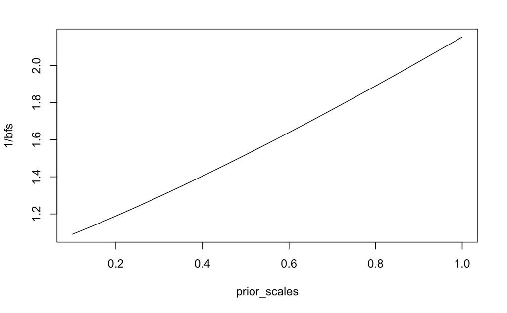

```r
prior_scales = seq(0.1,1,by = 0.05)
bfs = vector('numeric',length=length(prior_scales))
for(i in seq_along(prior_scales)){
  bfs[i] = ttestBF(formula=dv ~ gender,data=df_sub1,rscale = prior_scales[i])
}
plot(prior_scales,1/bfs,type='l')
```

We can have access to the actual samples from the posterior distributions of the parameters by calling the `posterior` function on the BF object.

```r
post_chains = posterior(bf,iterations = 5000)
```

```
0                                                                                                   %
|----|----|----|----|----|----|----|----|----|----|
```

```r
summary(post_chains)
```

```
Iterations = 1:5000
Thinning interval = 1
Number of chains = 1
Sample size per chain = 5000

1. Empirical mean and standard deviation for each variable,
   plus standard error of the mean:

                Mean        SD  Naive SE Time-series SE
mu            5.5044    0.4338  0.006135       0.006135
beta (F - M) -0.4754    0.7056  0.009979       0.010659
sig2          2.9517    1.2078  0.017080       0.019241
delta        -0.2934    0.4193  0.005930       0.006337
g            90.7103 6203.0446 87.724298      87.724298

2. Quantiles for each variable:

                 2.5%     25%     50%      75%   97.5%
mu            4.65545  5.2140  5.4988  5.78838  6.3709
beta (F - M) -1.96827 -0.9034 -0.4570 -0.01775  0.8489
sig2          1.41631  2.1130  2.6915  3.50902  5.9763
delta        -1.19672 -0.5525 -0.2738 -0.01047  0.4715
g             0.08158  0.2411  0.4909  1.24133 15.2626
```

- `mu`= grand mean
- `beta`= $mu_{F}$ - $mu_{M}$
- `sig2`= pooled variance
- `delta`= effect size

$$delta = \frac{beta}{\sqrt{sig2}}$$

Let’s take a look at the posterior distribution of the effect size $\delta$ and plot the 95% highest density interval as two vertical lines using the `hdi` function from package `HDInterval`. You see that the HDI includes the 0 which is another sign for us to stay with $H_{0}$.

```r
post_samples = data.frame(post_chains[,1:4])
dim(post_samples)
```

```
[1] 5000    4
```

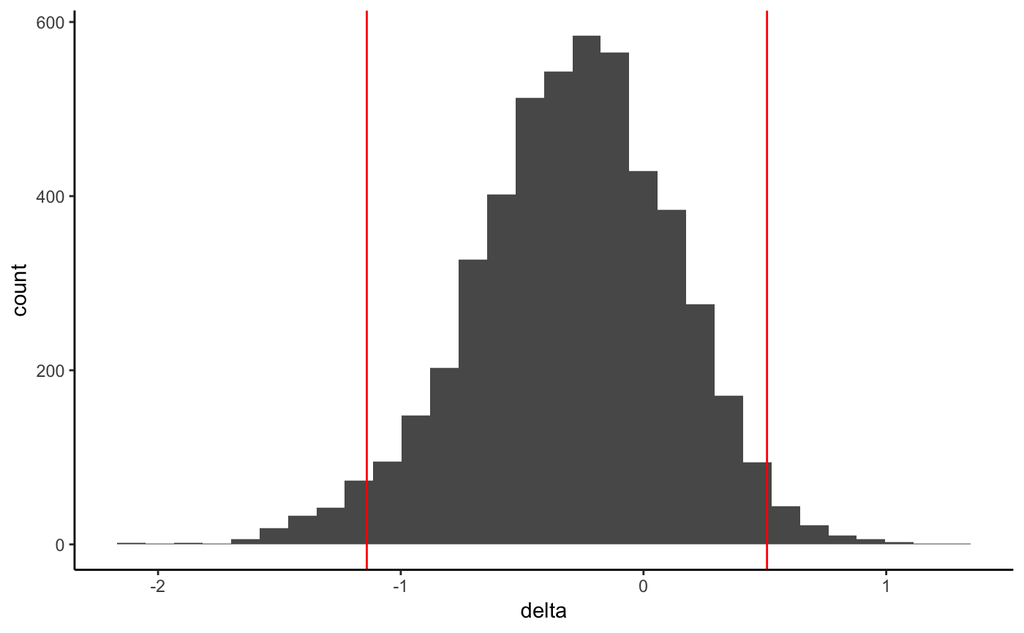

```r
hdint = hdi(post_samples$delta)
ggplot(post_samples,aes(x=delta)) +
    geom_histogram() +
    geom_vline(xintercept = hdint[1],color='red')+
    geom_vline(xintercept = hdint[2],color='red')+
    theme_classic()
```

## 1.2 paired samples

The paired samples t-test can be used when we want to compare two related groups. We test whether the difference in means differs significantly from zero.

$$H_{0}: \mu_{d} = 0$$

where *d* stands for *difference*.

Note that instead of running a paired samples t-test, we could instead compute all pairwise differences and run a one-sample t-test to check if the difference scores differ from 0.

### 1.2.1 frequentist

Let’s bring the data into the right format and pick only pre-test and follow-up test. This is off-topic so feel free to just skip over this part.

```r
df_sub2 = df %>%
    group_by(id,phase) %>%
    summarise(dv=mean(value)) %>%
    spread(phase,dv)
head(df_sub2)
```

| id | fup | post | pre |
| --- | --- | --- | --- |
| 1 | 3 | 3 | 2 |
| 2 | 4 | 3 | 4 |
| 3 | 7 | 5 | 6 |
| 4 | 4 | 3 | 5 |
| 5 | 4 | 6 | 4 |
| 6 | 9 | 9 | 8 |

Run the `ttestPS` function. See https://www.jamovi.org/jmv/ttestps.html for further information about the function.

```r
ttestPS(data=df_sub2,
        pairs = list(list(i1 = 'pre', i2 = 'post')),
        effectSize =T,
        desc=T)
```

```
 PAIRED SAMPLES T-TEST

 Paired Samples T-Test
 ─────────────────────────────────────────────────────────────────────────
                                 statistic    df      p        Cohen's d
 ─────────────────────────────────────────────────────────────────────────
   pre    post    Student's t        -3.15    15.0    0.007       -0.787
 ─────────────────────────────────────────────────────────────────────────


 Descriptives
 ─────────────────────────────────────────────────
           N     Mean    Median    SD      SE
 ─────────────────────────────────────────────────
   pre     16    4.38      4.00    1.63    0.407
   post    16    5.75      5.50    1.98    0.496
 ─────────────────────────────────────────────────
```

### 1.2.2 bayesian

As with the independent samples t-test, using the `BayesFactor` package for the paired t-test is super easy. Since we access the relevant columns directly, there is no need for the `data` argument.

```r
ttestBF(x=df_sub2$pre,y=df_sub2$post,paired=T)
```

```
Bayes factor analysis
--------------
[1] Alt., r=0.707 : 7.702987 ±0%

Against denominator:
  Null, mu = 0
---
Bayes factor type: BFoneSample, JZS
```

The Bayes factor states that $H_{1}$ is 7.7 more likely than $H_{0}$ which can be interpreted as substantial support for $H_{1}$.

# 2 ANOVA

In this section, you will see how to compute Bayes factors for factorial designs. For all “frequentist ANOVAs”, we use the `afex` package.

## 2.1 One-way between-subjects

The one-way ANOVA with only one between-subjects factor is the simplest extension of the independent samples t-test where you have more than two levels of a factor.

### 2.1.1 frequentist

`afex` lets you test all kind of designs using a very straightforward syntax. As you’ll see below, testing solely between-subjects designs even if the data are stored in long-format is not a problem. We only get a warning message stating: *More than one observation per cell, aggregating the data using mean*, which tells us that we probably have one or more within-subject factors in our data.

```r
(fit01f = aov_ez(dv='value',between='treatment',id='id',data=df))
```

```
More than one observation per cell, aggregating the data using mean (i.e, fun_aggregate = mean)!Contrasts set to contr.sum for the following variables: treatment
```

```
Anova Table (Type 3 tests)

Response: value
     Effect    df  MSE      F ges p.value
1 treatment 2, 13 2.14 2.91 + .31     .09
---
Signif. codes:  0 ‘***’ 0.001 ‘**’ 0.01 ‘*’ 0.05 ‘+’ 0.1 ‘ ’ 1
```

The Anova Table shows tests the main effect of `treatment` and displays numerator and denominator degrees of freedom, the mean square error (MSE), the F value, $\eta_{g}^{2}$, and the corresponding p-value.

`afex` automatically reshapes the data into wide-format:

```r
head(fit01f$data$wide)
```

|  | id | treatment | . |
| --- | --- | --- | --- |
| 1 | 1 | control | 2.666667 |
| 2 | 2 | control | 3.666667 |
| 3 | 3 | control | 6.000000 |
| 4 | 4 | control | 4.000000 |
| 5 | 5 | control | 4.666667 |
| 6 | 6 | A | 8.666667 |

In the newest version of `afex`, it is now possible to plot the results using `afex_plot`:

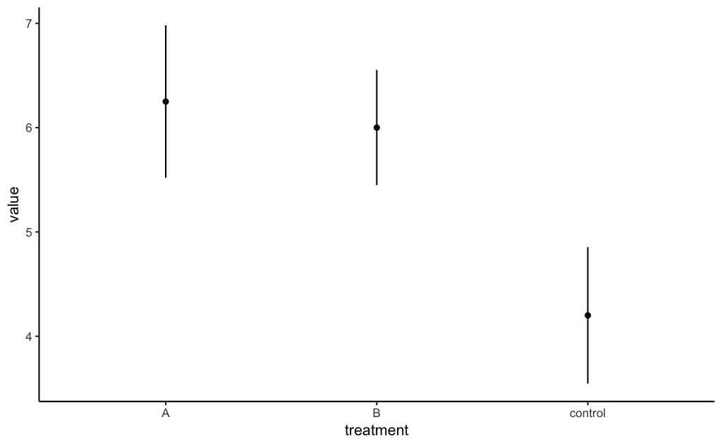

```r
afex_plot(fit01f,x='treatment',data_plot=F,error_ci=F)+
  theme_classic()
```

### 2.1.2 bayesian

Notice that `anovaBF` is not able to aggregate the data in order to fit the correct model. In order to be able to compare the above analysis with the respective bayesian analysis, we need to pass the data in wide-format to the `anovaBF` function.

```r
(fit01b = anovaBF(.~treatment,data=fit01f$data$wide))
```

```
Bayes factor analysis
--------------
[1] treatment : 1.280736 ±0.01%

Against denominator:
  Intercept only
---
Bayes factor type: BFlinearModel, JZS
```

Let’s take a look at the MCMC chains and the parameters of the ANOVA model.

```r
post_chains = posterior(fit01b,iterations=5000)
```

```
0                                                                                                   %
|----|----|----|----|----|----|----|----|----|----|
```

```r
summary(post_chains)
```

```
Iterations = 1:5000
Thinning interval = 1
Number of chains = 1
Sample size per chain = 5000

1. Empirical mean and standard deviation for each variable,
   plus standard error of the mean:

                     Mean     SD Naive SE Time-series SE
mu                 5.4869 0.4036 0.005708       0.005708
treatment-A        0.4377 0.4835 0.006838       0.007589
treatment-B        0.3459 0.4269 0.006037       0.006498
treatment-control -0.7836 0.5090 0.007199       0.009559
sig2               2.5214 1.1615 0.016425       0.019937
g_treatment        0.8832 2.5759 0.036428       0.041488

2. Quantiles for each variable:

                      2.5%      25%     50%     75%  97.5%
mu                 4.69847  5.22993  5.4804  5.7450 6.2761
treatment-A       -0.43757  0.10421  0.4222  0.7450 1.4473
treatment-B       -0.49462  0.07724  0.3332  0.6114 1.2146
treatment-control -1.82851 -1.11114 -0.7560 -0.4298 0.1264
sig2               1.14817  1.77343  2.2630  2.9611 5.3771
g_treatment        0.05469  0.16353  0.3442  0.7632 4.9821
```

We can recover the parameters shown in the output above. The parameters (`treatment-control`, `treatment-A`, `treatment-B`) are standardized effects whereas `mu` is the grand mean.

The cell means can be recovered with:

$$mu_{control} = \texttt{mu} + (\texttt{treatment-control} * \sqrt{\texttt{sig2}})$$
$$mu_{A} = \texttt{mu} + (\texttt{treatment-A} * \sqrt{\texttt{sig2}})$$
$$mu_{B} = \texttt{mu} + (\texttt{treatment-B} * \sqrt{\texttt{sig2}})$$

## 2.2 One-way within subjects

### 2.2.1 frequentist

Using `afex`, we only have to switch from the `between` to the `within` argument. The Greenhouse-Geisser correction for the violation of sphericity is applied by default. We will use `phase` as the only within-subjects factor.

```r
(fit02f = aov_ez(dv='value',within='phase',id='id',data=df))
```

```
More than one observation per cell, aggregating the data using mean (i.e, fun_aggregate = mean)!
```

```
Anova Table (Type 3 tests)

Response: value
  Effect          df  MSE         F ges p.value
1  phase 1.54, 23.16 1.46 14.85 *** .18   .0002
---
Signif. codes:  0 ‘***’ 0.001 ‘**’ 0.01 ‘*’ 0.05 ‘+’ 0.1 ‘ ’ 1

Sphericity correction method: GG
```

There is a significant main effect of `phase`. We run pairwise comparisons to see which of the 3 groups (pre, post, fup) really differ from each other. First, we generate the reference grid which simply displays all cell means (column `emmean`)

```r
(ref_grid = emmeans(fit02f,~phase))
```

```
 phase emmean        SE    df lower.CL upper.CL
 fup    6.375 0.4632314 23.66 5.418212 7.331788
 post   5.750 0.4632314 23.66 4.793212 6.706788
 pre    4.375 0.4632314 23.66 3.418212 5.331788

Confidence level used: 0.95
```

```r
pairs(ref_grid)
```

```
 contrast   estimate        SE df t.ratio p.value
 fup - post    0.625 0.3754627 30   1.665  0.2352
 fup - pre     2.000 0.3754627 30   5.327  <.0001
 post - pre    1.375 0.3754627 30   3.662  0.0027

P value adjustment: tukey method for comparing a family of 3 estimates
```

With `afex_plot`, it is also possible to display within-subject error bars:

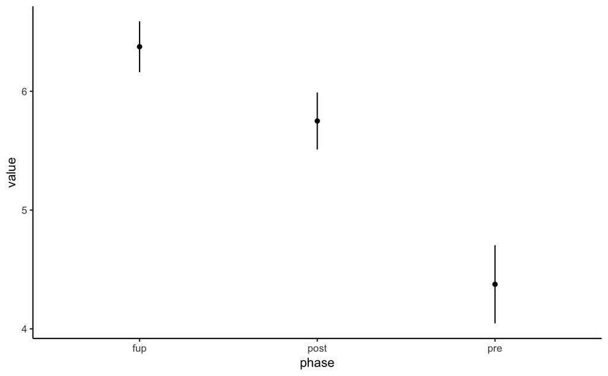

```r
afex_plot(fit02f,x='phase',error='within',data_plot=F,error_ci = F)+
  theme_classic()
```

### 2.2.2 bayesian

As already seen, in order to run the same analysis using `anovaBF`, you need to make sure that the data is already aggregated.

```r
df_wide = df %>% group_by(id,phase) %>% summarise(value=mean(value))
head(df_wide)
```

| id | phase | value |
| --- | --- | --- |
| 1 | fup | 3 |
| 1 | post | 3 |
| 1 | pre | 2 |
| 2 | fup | 4 |
| 2 | post | 3 |
| 2 | pre | 4 |

One special thing you have to keep in mind when running within-subject ANOVAs using the `BayesFactor` package is that you need don’t really conduct a within-subjects ANOVA but rather a linear mixed-effects models. Therefore, you have to add the subject identifier column (here named `id`) as an additional predictor variable. Also, you have to specify that `id` is a random factor.

```r
df_wide$id = factor(df_wide$id)
(fit02b = anovaBF(value ~ phase + id, whichRandom = 'id',data=df_wide))
```

```
data coerced from tibble to data frame
```

```
Bayes factor analysis
--------------
[1] phase + id : 583.6143 ±0.54%

Against denominator:
  value ~ id
---
Bayes factor type: BFlinearModel, JZS
```

Let’s see the parameters underlying the model. Here, we draw the posterior samples and convert everything to a dataset (see below).

```r
chaindf = data.frame(posterior(fit02b,iterations = 5000))
```

```
0                                                                                                   %
|----|----|----|----|----|----|----|----|----|----|
```

```r
head(chaindf)
```

|  | mu | phase.fup | phase.post | phase.pre | id.1 | id.2 | id.3 | id.4 | id.5 | id.6 | id.7 | id.8 | id.9 | id.10 | id.11 | id.12 | id.13 | id.14 | id.15 | id.16 | sig2 | g_phase | g_id |
| --- | --- | --- | --- | --- | --- | --- | --- | --- | --- | --- | --- | --- | --- | --- | --- | --- | --- | --- | --- | --- | --- | --- | --- |
| 1 | 5.687492 | 0.4805720 | 0.2558557 | -0.7364277 | -2.399501 | -0.6896734 | -0.1722796 | -1.0195073 | -0.139433476 | 2.248642 | 0.2585696 | -0.7397651 | 0.8809260 | -0.22171319 | -0.8019717 | 2.484508 | 0.2432486 | -1.3624480 | -0.299386800 | 0.09770685 | 1.758582 | 0.1442645 | 1.0307178 |
| 2 | 4.860163 | 0.6986288 | -0.1239831 | -0.5746457 | -1.505911 | -1.4551599 | 0.5412254 | -0.5448111 | -0.329609230 | 2.108501 | 2.0065368 | -0.6004222 | 0.4926376 | 1.09507916 | -0.4155781 | 2.130428 | 2.0621774 | -0.9033886 | 1.521392951 | 1.57409430 | 1.482527 | 0.1919955 | 1.2442330 |
| 3 | 5.567186 | 0.8993120 | 0.1988047 | -1.0981167 | -1.911199 | -1.7511777 | 0.3540002 | -0.2736468 | 0.006085986 | 2.166962 | 0.8067890 | -0.3405050 | 0.2571464 | 0.47304240 | -0.1946610 | 1.799580 | 1.3306707 | -0.7929200 | 1.105212682 | 1.02159558 | 1.895182 | 0.3416238 | 0.5593787 |
| 4 | 5.457307 | 0.6902720 | 0.4963103 | -1.1865823 | -2.302827 | -0.9316748 | -0.7047937 | -1.5772302 | 0.325176774 | 0.753519 | 1.8424364 | 0.1637267 | -0.3893007 | 0.08112017 | -0.7028419 | 1.497827 | 0.7227532 | -1.0273052 | -0.724137925 | -0.08879739 | 1.942405 | 0.2769520 | 0.5552838 |
| 5 | 5.262552 | 0.6891139 | 0.3970816 | -1.0861955 | -1.394298 | -1.8400802 | -0.3784190 | -0.6571496 | -0.898495042 | 1.992965 | 2.6325259 | -0.0125784 | -1.4543482 | 0.80710569 | -0.3151382 | 1.509678 | 0.8843209 | -0.7233265 | -0.411783144 | 1.73991947 | 2.333387 | 4.3890062 | 0.9059327 |
| 6 | 6.130099 | 0.8324422 | 0.3096853 | -1.1421274 | -1.219645 | -1.0862691 | 0.3188429 | -1.6044735 | -0.797979509 | 2.525406 | -0.2308633 | -1.3661381 | -2.1571905 | 0.04542245 | 1.3929295 | -0.230122 | -1.2548828 | -0.7383998 | 0.009555316 | 0.20333915 | 2.922265 | 0.2426278 | 0.2944301 |

What if we want to take a look at the posterior distribution of the difference of follow-up-test and post-test?

Well, we can generate this distribution by using the formula above.

```r
chaindf = chaindf %>% mutate(fup_mean = chaindf$mu  + (chaindf$phase.fup * sqrt(chaindf$sig2)),
                            post_mean = chaindf$mu  + (chaindf$phase.post *sqrt(chaindf$sig2)),
                            fup_vs_post = fup_mean - post_mean)
```

And plot the posterior. The HDInterval comes to the same conclusion (no difference since 0 is inside the 95% credible interval) as the post-hoc test for the frequentist ANOVA.

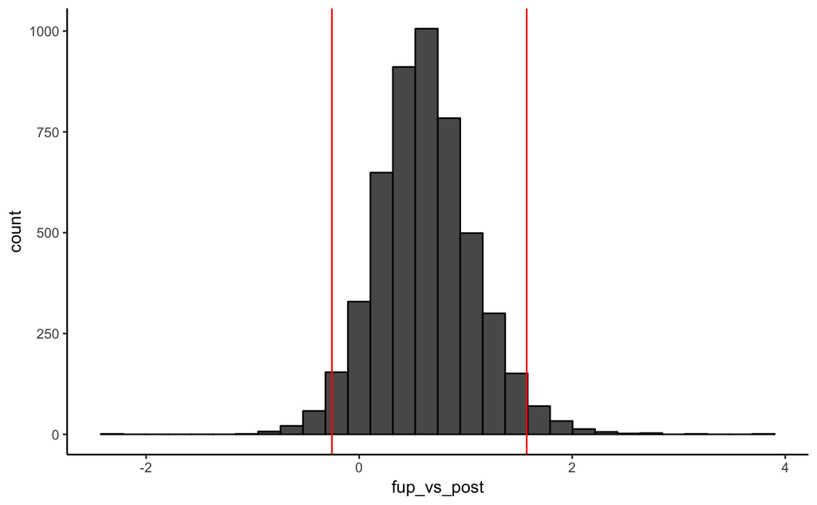

```r
hdint = hdi(chaindf$fup_vs_post)
ggplot(chaindf,aes(x=fup_vs_post)) +
    geom_histogram(colour='black') +
    geom_vline(xintercept = hdint[1],color='red')+
    geom_vline(xintercept = hdint[2],color='red')+
    theme_classic()
```